# Puzzle Solving Case Study:

Latinos and Discrimination

Sergio I Garcia-Rios

## Preliminary set up

Let’s load the data. We are going to use the Latino National Survey for this workshop. This particular version of the LNS comes in `.dta` format which is the extension used for a statistical package called `Stata`

`Stata` is very popular and powerful and many statisticians and social scientist use it. I used to swear by it. But then, I met `R` and… well things change.

The good thing is that R allows you to read in many different files, yes there’s a pack for that!

### Load Data

OK now let’s really lead the data, I use `read_dta` here but depending on the extension of your file that will change.

```r
lns <-  read_dta("lns_full.dta")
```

This is going to get somewhat technical but just trust me here… for this Workshop we are going to do some data transformation, if your data came as a Stata file sometimes is good to run this command so you can convert all files into factors. You can do that also just for a single variable (I actually recommend this) when you need to graph or something like that.

```r
lns <- haven::as_factor(lns, only_labelled = TRUE)
```

## Analysis

Now we are ready to start our analysis. Recently a a very interesting came out, [here](https://www.dol.gov/_sec/media/reports/hispaniclaborforce/) and shows that while Latinos face do face higher rates of unemployment they seem to be significantly more pessimistic about their economic outlook than other Whites and Blacks. That’s sounds interesting and I think it deserves further exploration.

### Main Issue

Let’s begin by looking at what Latinos think is the main issue facing the country. The variable is `natprob`

```r
lns %>% count(natprob) %>%
  mutate(pct = prop.table(n)) %>% pander()
```

| natprob | n | pct |
| --- | --- | --- |
| the economy | 1222 | 0.1415 |
| unemployment/jobs | 377 | 0.04366 |
| education/public schools | 250 | 0.02896 |
| crime | 187 | 0.02166 |
| drugs | 146 | 0.01691 |
| health care | 82 | 0.009497 |
| race relations | 213 | 0.02467 |
| values/family values/morality | 77 | 0.008918 |
| budget deficit | 37 | 0.004285 |
| social security/care for the elderly | 32 | 0.003706 |
| illegal immigration | 907 | 0.105 |
| affirmative action | 9 | 0.001042 |
| welfare/welfare reform | 15 | 0.001737 |
| environment | 23 | 0.002664 |
| political system/corruption/scandal | 140 | 0.01621 |
| foreign policy/international concerns/national defense | 180 | 0.02085 |
| abortion | 11 | 0.001274 |
| something else (specify) | 865 | 0.1002 |
| dk/rf | 1079 | 0.125 |
| iraq war | 2782 | 0.3222 |

Seems like the Iraq war is the main issue at the bottom pf the table. Let’s try to plot it with a bar-graph

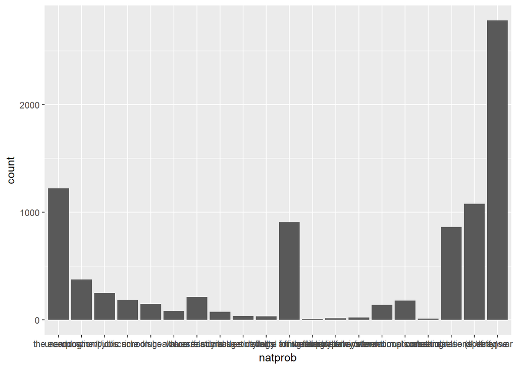

```r
ggplot(lns, aes(x = natprob)) +
  geom_bar()
```

WOW… That looks pretty bad, let’s try to improve it by flipping the axes with `coord_flip`

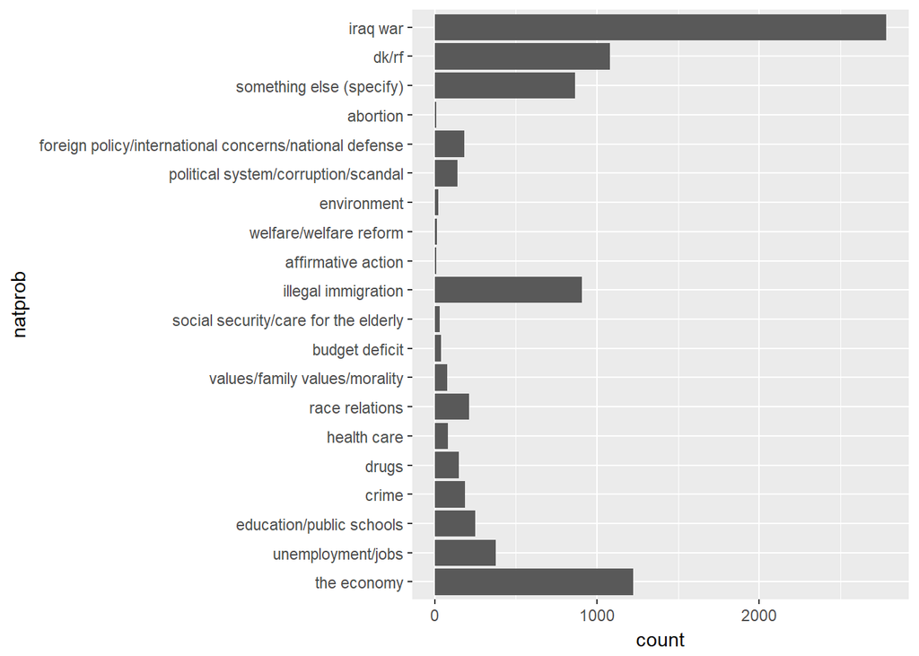

```r
ggplot(lns, aes(x = natprob)) +
  geom_bar() +
  coord_flip()
```

That’s better but we can make it much better if we do some recoding to the `natprob` variable.

- First we create a new variable called `natprob_r`
- This variable is going to be exactly the same as `natprob` but ordered by frequency. We do that with `fct_infreq`
- Then, we reverse the order with `fct_rev` so that it goes from high to low

```r
lns <- lns %>% mutate(natprob_r =
                        natprob %>%
                        fct_infreq() %>%
                        fct_rev())
```

Now we can create the graph, notice that I am adding some other elements:

- I added another aesthetic: `fill` and specified that I wanted the bar to be filled with the color blue
- I also added a new `theme`. I am at point in my life where`theme_minimal` is my favorite but I also had stage in my life where I liked `theme_bw`… things change…

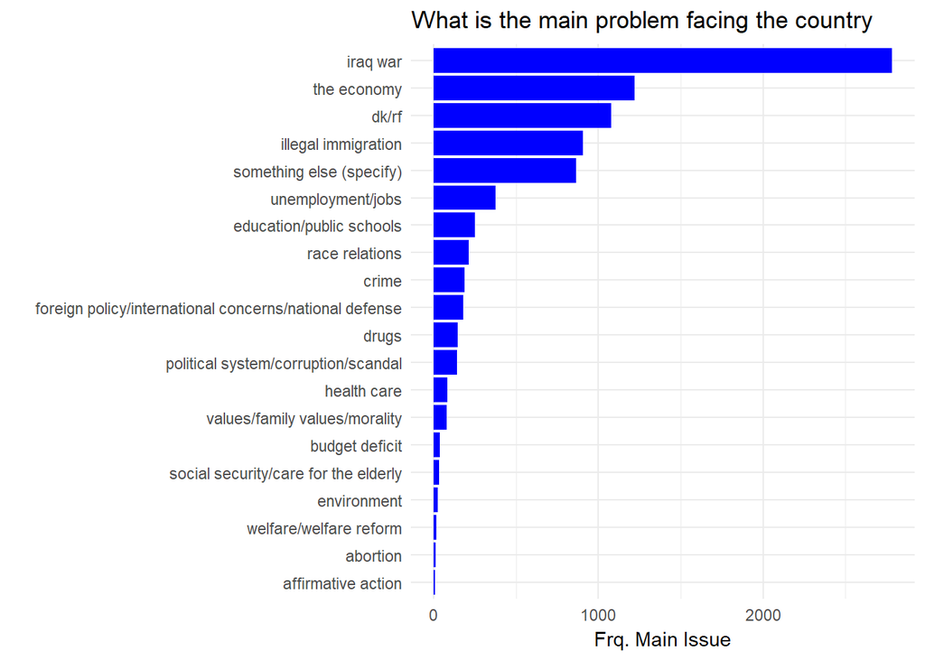

```r
ggplot(lns, aes(x = natprob %>%
                  fct_infreq() %>%
                        fct_rev()
                )) +
  geom_bar( fill = "blue") +  # added blue as the color for the bars
  coord_flip() + # still wnat the coordinted flipped
  labs(x = "",
       y = "Frq. Main Issue",
       title= "What is the main problem facing the country") +  # here I can specify labels and titles
  theme_minimal()
```

What about the issues for Latinos? Let’s do the same but now, I actually don’t really Like that blue color, so let’s borrow a nice green color from [ColorBrewer](http://colorbrewer2.org)

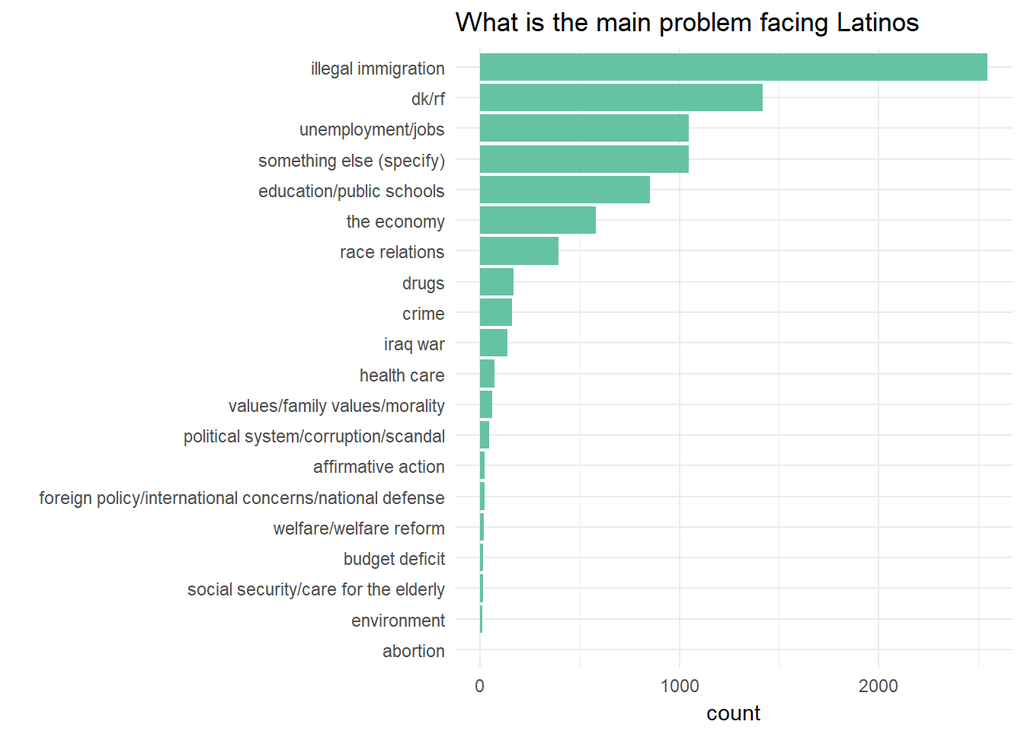

```r
ggplot(lns, aes(x =
                  latprob %>%
                  fct_infreq %>%
                  fct_rev())) +
  geom_bar(fill = "#66c2a5") +
  coord_flip() +
  labs(x = "",
       title= "What is the main problem facing Latinos") +
  theme_minimal()
```

### Poor people can get ahead if they work hard

- How strongly do you agree or disagree with the following: *Poor people can get ahead in life if they work hard*

Let’s explore that variable

```r
prop.table(table(lns$poordisc))
```

```
##
## strongly disagree somewhat disagree    somewhat agree    strongly agree
##             0.033             0.033             0.183             0.722
##                dk
##             0.028
```

Well seems like most Latinos agree that working hard will get them ahead in life but let’s see more in depth because Latinos are not a monolithic group.

Let’s look at them by generation. I created this variable `newgen` that breaks down Latinos by generation:

```r
prop.table(table(lns$newgen))
```

```
##
##     1   1.5     2   2.5     3     4
## 0.642 0.067 0.118 0.029 0.066 0.078
```

Now, lets look at both. That is, what Latinos think about their economic chances if they work hard by generation. Notice I am adding a `2` at the end, this makes the `prop.table` show percentages by column.

```r
table(lns$poordisc, lns$newgen)
```

```
##
##                        1  1.5    2  2.5    3    4
##   strongly disagree  135   20   51    8   32   37
##   somewhat disagree  121   13   46   19   35   51
##   somewhat agree     879  103  209   57  145  185
##   strongly agree    4227  422  674  161  343  384
##   dk                 159   17   34    8   14   12
```

```r
prop.table(table(lns$poordisc,
                 lns$newgen), 2)
```

```
##
##                         1   1.5     2   2.5     3     4
##   strongly disagree 0.024 0.035 0.050 0.032 0.056 0.055
##   somewhat disagree 0.022 0.023 0.045 0.075 0.062 0.076
##   somewhat agree    0.159 0.179 0.206 0.225 0.255 0.277
##   strongly agree    0.766 0.734 0.665 0.636 0.603 0.574
##   dk                0.029 0.030 0.034 0.032 0.025 0.018
```

You can see that the percentage of those strongly agreeing drops from 77 to 57 as you go across generations. Also, notice that `dk`… it means don’t know, we don’t need it so let’s drop it using `recode`

```r
lns <- lns %>%
  mutate(poordisc_r =
           recode(poordisc,
                  "dk" = NA_character_))
```

Let’s visualize these data, but first we need to do some recoding to the variable to make sure that the values appear in the correct order, usually they do but in case they don’t I want to show you how to specify the order.

- So, again, we go the dataframe “lns”,
- **then** with `mutate` create a variable called `poor_r`,
- **then** specify the order with `re_level`.

```r
lns <- lns %>% mutate(poord_r =
                        fct_relevel(poordisc_r, "strongly disagree", "somewhat disagree",
                                            "somewhat agree", "strongly agree"))
```

Now we create a proportion table like we did with proptable but now we put it in a data frame called `poor_can`.

```r
poor_can<- lns %>%
  group_by(newgen) %>%
  count(poord_r) %>%
  mutate(prop = prop.table(n)) %>%
  na.omit()
```

And this is what it looks like:

```r
poor_can
```

```
## # A tibble: 24 x 4
## # Groups:   newgen [6]
##    newgen           poord_r     n  prop
##     <dbl>            <fctr> <int> <dbl>
##  1    1.0 strongly disagree   135 0.024
##  2    1.0 somewhat disagree   121 0.022
##  3    1.0    somewhat agree   879 0.159
##  4    1.0    strongly agree  4227 0.766
##  5    1.5 strongly disagree    20 0.035
##  6    1.5 somewhat disagree    13 0.023
##  7    1.5    somewhat agree   103 0.179
##  8    1.5    strongly agree   422 0.734
##  9    2.0 strongly disagree    51 0.050
## 10    2.0 somewhat disagree    46 0.045
## # ... with 14 more rows
```

Now we are ready to create a graph using those proportions, that is, the `poor_can` mini data set that we created.

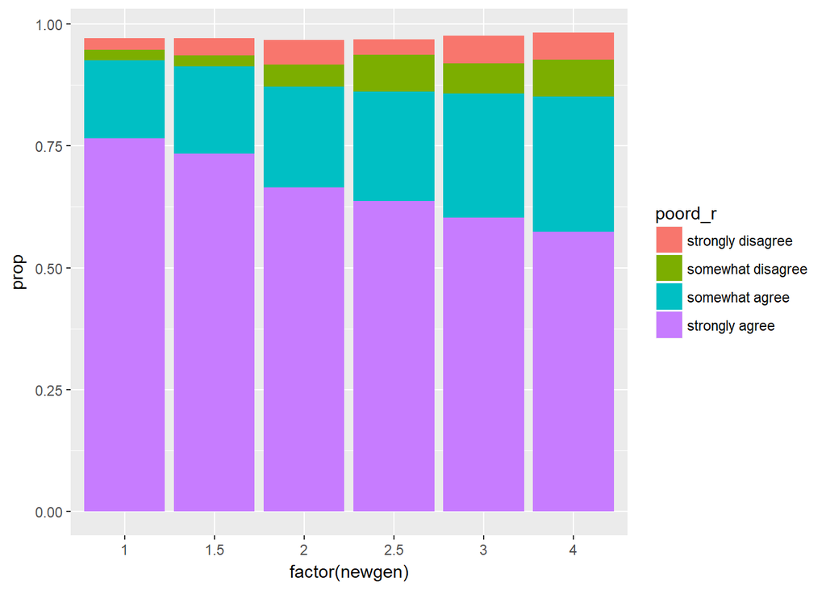

```r
ggplot(poor_can, aes(x=factor(newgen),
                     y = prop, fill = poord_r)) +
  geom_bar(stat= "identity")
```

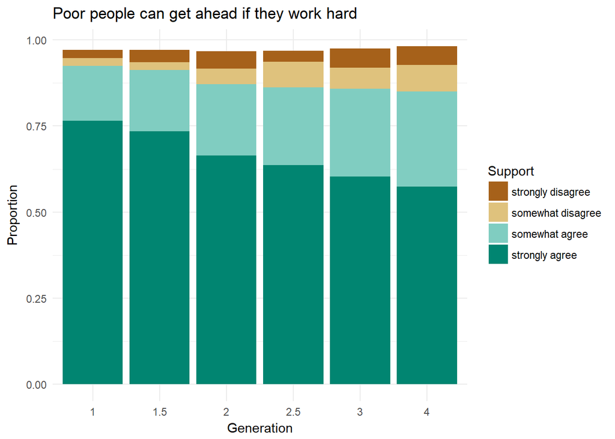

```r
ggplot(poor_can, aes(x = factor(newgen), y = prop,
                         fill = poord_r)) +
  geom_bar(stat= "identity") +
  labs(x = "Generation",
       y = "Proportion",
       title= "Poor people can get ahead if they work hard",
       fill =  "Support") +
  scale_fill_brewer(palette = "BrBG") +
  theme_minimal()
```

### Latinos can get ahead if they work hard

They also asked a similar question but related to Latinos specifically:

- How strongly do you agree or disagree with the following: *Latinos can get ahead in life if they work hard*

The name of he variable is `latdic`. We are going to do the same graph but now with this variable, notice that I am adding a new line to specify labels on the x axis with `scale_x_discrete` (those are called axis ticks, by the way)

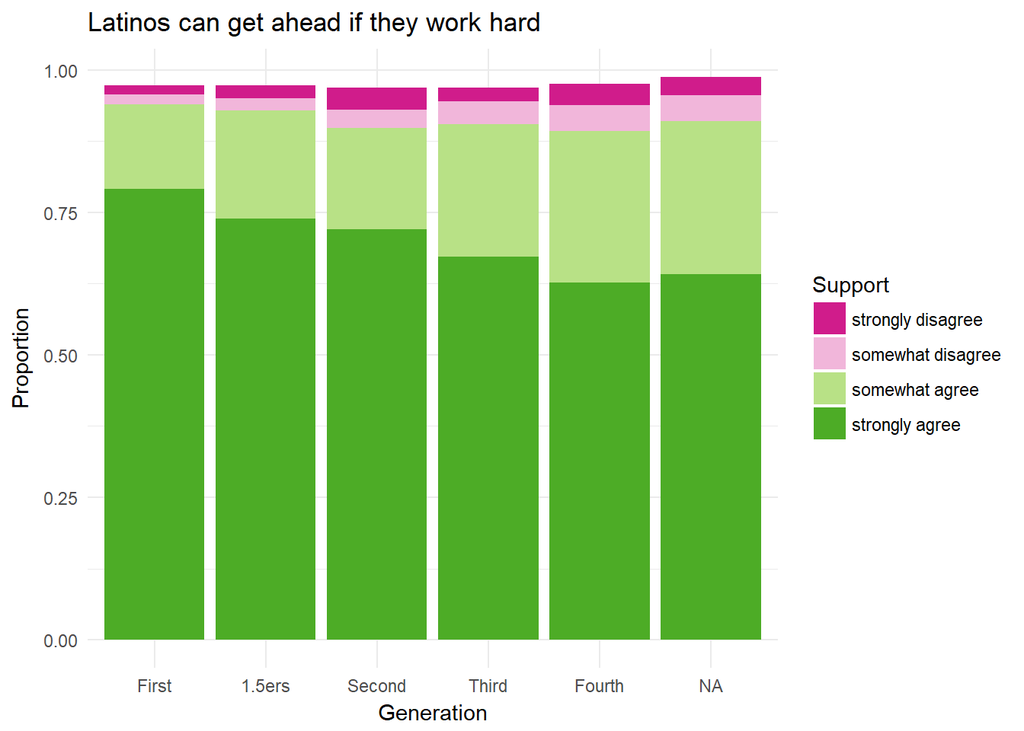

```r
lns <- lns %>%  mutate(latdisc_r =  recode(latdisc, 'dk' = NA_character_))


latinos_can<- lns %>%
  group_by(newgen) %>%
  count(latdisc_r) %>%
  mutate(prop = prop.table(n)) %>%
  na.omit()



ggplot(latinos_can, aes(x = factor(newgen), y = prop,
                         fill = latdisc_r)) +
  geom_bar(stat= "identity") +
  theme_minimal() +
  labs(x = "Generation",
       y = "Proportion",
       title= "Latinos can get ahead if they work hard",
       fill = "Support") +
  scale_fill_brewer(palette = "PiYG") +
  scale_x_discrete(labels = c("First", "1.5ers", "Second", "Third", "Fourth"))
```

### Discrimantion

I want to investigate this further, and I think it has to do with perceptions of discrimination. The LNS asked Latinos four questions to see if they have experienced some kind of discrimination. These are the questions:

- Have you ever … been unfairly fired or denied a job or promotion?
- Have you ever … been unfairly treated by the police?
- Have you ever … been unfairly prevented from moving into a neighborhood (vecindario o barrio) because the landlord or a realtor refused to sell or rent you a house or apartment?
- Have you ever … been treated unfairly or badly at restaurants or stores?

IF they said yes to **any** of those, they followed up asking why they think they were discriminated, the variable is `whydisc`

```r
lns %>% count(whydisc)
```

```
## # A tibble: 10 x 2
##                    whydisc     n
##                     <fctr> <int>
##  1            being latino   856
##  2      being an immigrant   232
##  3    your national origin   220
##  4 your language or accent   378
##  5         your skin color   362
##  6             your gender    66
##  7                your age   105
##  8                   other   438
##  9                   dk/na   211
## 10                    <NA>  5766
```

Seems like simply being Latino is the main reason why Latinos report they have been discriminated.

Now let’s look at that across generations, again we begin by recoding that `dk/na` with `mutate` and `Recode`

```r
lns<- lns %>% mutate(whydisc_r = recode(whydisc, "dk/na" = NA_character_))
```

Now look at the proportion table

```r
prop.table(table(lns$whydisc_r,lns$newgen), 2) %>% pander()
```

Table continues below

|  | 1 | 1.5 | 2 | 2.5 | 3 |
| --- | --- | --- | --- | --- | --- |
| **being latino** | 0.3206 | 0.3756 | 0.3517 | 0.3394 | 0.2913 |
| **being an immigrant** | 0.1487 | 0.07317 | 0.02871 | 0.009174 | 0 |
| **your national origin** | 0.06054 | 0.1122 | 0.1077 | 0.08257 | 0.1299 |
| **your language or accent** | 0.2242 | 0.09756 | 0.07416 | 0.07339 | 0.03543 |
| **your skin color** | 0.07549 | 0.1366 | 0.177 | 0.2202 | 0.2126 |
| **your gender** | 0.01719 | 0.01951 | 0.02871 | 0.02752 | 0.03543 |
| **your age** | 0.02691 | 0.04878 | 0.03589 | 0.05505 | 0.06693 |
| **other** | 0.1263 | 0.1366 | 0.1962 | 0.1927 | 0.2283 |

|  | 4 |
| --- | --- |
| **being latino** | 0.2747 |
| **being an immigrant** | 0.01235 |
| **your national origin** | 0.08951 |
| **your language or accent** | 0.03086 |
| **your skin color** | 0.2438 |
| **your gender** | 0.04321 |
| **your age** | 0.06481 |
| **other** | 0.2407 |

You can see interesting patterns:

- For example, being Latino seems to be salient across all generations but
- Accent and being immigrant is, as expected only salient among first generations
- But while later generations will not have access and wouldn’t be immigrants they still feel discriminated an now seem to attribute it to their skin color

For example if someone said yes to

- unfairly fired or denied a job or promotion` **and**
- also said yes to `been treated unfairly or badly at restaurants or stores`
- they would have “collected” two `1`’s so ending up with a discrimination score of `2`

This is how you do the index:

```
lns <- lns %>% mutate(discindex  = dfired_r + dbadpol_r+ dhousing_r+drestaur_r)
```

Let’s take a look:

```r
prop.table(table(lns$discindx))
```

```
##
##     1     2     3     4
## 0.774 0.179 0.024 0.023
```

How does that look across generations (notice how here I am multiplying by 100, to make it look like percentages)

```r
prop.table(table(lns$discindx, lns$newgen), 2)*100
```

```
##
##        1  1.5    2  2.5    3    4
##   1 81.3 76.0 74.3 69.4 64.3 64.9
##   2 15.3 19.5 18.4 24.1 27.2 27.2
##   3  1.8  2.1  3.3  4.1  4.7  4.5
##   4  1.6  2.3  4.1  2.4  3.8  3.3
```

## Regression and predicted probabilities

I am going to run now a regression using`poord_r` as my dependent variable. To do that I first have to tell R that this time the variable `poord_r` will be numeric

```r
lns$poord_r <- as.numeric(lns$poord_r)


summary(model1<-lm(poord_r ~ newgen, data = lns))
```

```
##
## Call:
## lm(formula = poord_r ~ newgen, data = lns)
##
## Residuals:
##    Min     1Q Median     3Q    Max
## -2.709 -0.350  0.291  0.291  0.650
##
## Coefficients:
##             Estimate Std. Error t value Pr(>|t|)
## (Intercept)  3.82822    0.01502   254.8   <2e-16 ***
## newgen      -0.11952    0.00827   -14.4   <2e-16 ***
## ---
## Signif. codes:  0 '***' 0.001 '**' 0.01 '*' 0.05 '.' 0.1 ' ' 1
##
## Residual standard error: 0.7 on 8355 degrees of freedom
##   (277 observations deleted due to missingness)
## Multiple R-squared:  0.0244, Adjusted R-squared:  0.0243
## F-statistic:  209 on 1 and 8355 DF,  p-value: <2e-16
```

The estimate -0.11952, so based on these data every subsequent generation would be around -0.11952 lower than the previous one.

We can use predict to extract the predicted probabilities.

-First we create a hypothetical case. -In this example I just want to look at First vs Second generations

```r
hypdata<- data.frame(newgen=c(1,2))
```

Here is the command. The result show that the predicted level (in a 1-4 scale) of saying that poor people can get ahead by working hard drops from 3.7 to 3.6 when you compare First vs Second

```r
predict(model1, hypdata)
```

```
##   1   2
## 3.7 3.6
```

I can also look at more than two, what about First, 1.5ers and Fourth

```r
hypdata<- data.frame(newgen=c(1, 1.5, 4))
predict(model1, hypdata)
```

```
##   1   2   3
## 3.7 3.6 3.4
```

Now I am going to run a full model including the following variables:

- Generation
- Our discrimination index
- Level of education
- Age
- Whether the respondent is Mexican
- Income
- whether the respondent is female

```r
summary(fullmodel <- lm(poord_r ~ newgen + discindx + trieduc + age + mexican + income + female, data = lns))
```

```
##
## Call:
## lm(formula = poord_r ~ newgen + discindx + trieduc + age + mexican +
##     income + female, data = lns)
##
## Residuals:
##     Min      1Q  Median      3Q     Max
## -2.9324  0.0105  0.1067  0.1514  2.4636
##
## Coefficients:
##              Estimate Std. Error t value Pr(>|t|)
## (Intercept)  4.667033   0.032093  145.42   <2e-16 ***
## newgen      -0.044805   0.007541   -5.94    3e-09 ***
## discindx    -0.751601   0.010335  -72.73   <2e-16 ***
## trieduc     -0.013688   0.008851   -1.55    0.122
## age          0.000809   0.000440    1.84    0.066 .
## mexican      0.038185   0.014388    2.65    0.008 **
## income      -0.001276   0.003669   -0.35    0.728
## female      -0.016312   0.013128   -1.24    0.214
## ---
## Signif. codes:  0 '***' 0.001 '**' 0.01 '*' 0.05 '.' 0.1 ' ' 1
##
## Residual standard error: 0.52 on 6414 degrees of freedom
##   (2212 observations deleted due to missingness)
## Multiple R-squared:  0.468,  Adjusted R-squared:  0.467
## F-statistic:  806 on 7 and 6414 DF,  p-value: <2e-16
```

Now for my hypothetical values I am only going to move generation and whether the respondent is Mexican the rest I am going to hold them at their mean

```r
hypdata_mex<- lns %>% with(expand.grid(newgen=c(1,4),
                     discindx = mean(discindx,  na.rm = TRUE),
                     trieduc = mean(trieduc,  na.rm = TRUE),
                     age = mean(age,  na.rm = TRUE),
                     mexican = c(0,1),
                     income = mean(income,  na.rm = TRUE),
                     female = mean(female,  na.rm = TRUE)))
```

This is what out hypothetical data looks like, one for each generation requested (1, 4) and one for each nationality (Mexican/non-Mexican)

```r
hypdata_mex
```

```
##   newgen discindx trieduc age mexican income female
## 1      1      1.3       2  41       0    3.5   0.55
## 2      4      1.3       2  41       0    3.5   0.55
## 3      1      1.3       2  41       1    3.5   0.55
## 4      4      1.3       2  41       1    3.5   0.55
```

Now I can get predicted probabilities for this full model with those two variables “moving”. I am also adding some confidence interval

```r
predict_df_mex <- predict(fullmodel, hypdata_mex, interval = "confidence", level = .90)
```

Let’s look at the result:

```r
predict_df_mex
```

```
##   fit lwr upr
## 1 3.6 3.6 3.7
## 2 3.5 3.5 3.5
## 3 3.7 3.7 3.7
## 4 3.5 3.5 3.6
```

- `fit` This is the estimated value
- `lwr` This is the lower bound in our confidence interval
- `upr` This is the upper bound in our confidence interval

And we have four rows, one for each hypothetical value that we wanted. To facilitate graphing I am going to add the `hypdata_mex` to the `predict_df_mex` using the command `cbind`

```r
plot_predicts_mex <- cbind(predict_df_mex, hypdata_mex)
```

It looks like this now

```r
plot_predicts_mex
```

```
##   fit lwr upr newgen discindx trieduc age mexican income female
## 1 3.6 3.6 3.7      1      1.3       2  41       0    3.5   0.55
## 2 3.5 3.5 3.5      4      1.3       2  41       0    3.5   0.55
## 3 3.7 3.7 3.7      1      1.3       2  41       1    3.5   0.55
## 4 3.5 3.5 3.6      4      1.3       2  41       1    3.5   0.55
```

With that mini dataset that I created I can make a nice graph

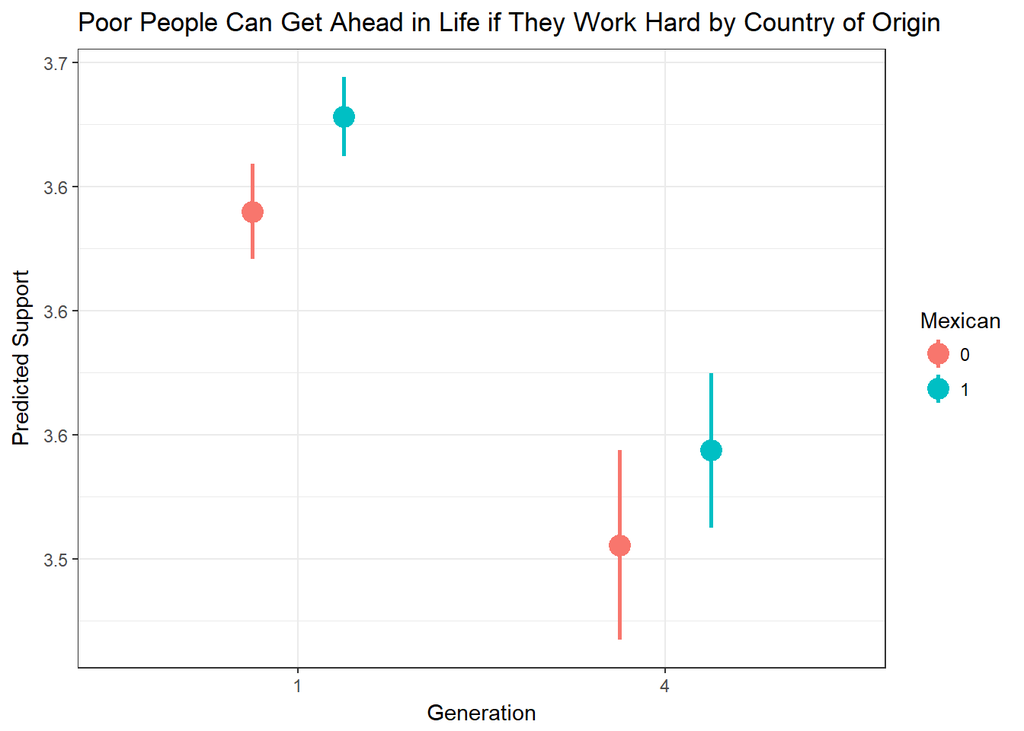

```r
ggplot(plot_predicts_mex, aes(y = fit, x = factor(newgen),
                              color = factor(mexican),
                          ymin = lwr,
                          ymax= upr)) +
  geom_pointrange(size = 1, position = position_dodge(width = .5)) +
  theme_bw() +
  labs(x = "Generation",
       y = "Predicted Support",
       title = "Poor People Can Get Ahead in Life if They Work Hard by Country of Origin",
       color =  "Mexican")
```

Now let’s look at discrimination. That’s the only variable I am going to “move” for this graph, the rest will be held at their mean.

```r
hypdata2<- lns %>% with(expand.grid(newgen= mean(newgen, na.rm = TRUE),
                     discindx = seq(1,4),
                     trieduc = mean(trieduc,  na.rm = TRUE),
                     age = mean(age,  na.rm = TRUE),
                     mexican = mean(mexican,  na.rm = TRUE),
                     income = mean(income,  na.rm = TRUE),
                     female = mean(female,  na.rm = TRUE)))

predict_df2 <- predict(fullmodel, hypdata2, interval = "confidence")
```

Now extract predicted probabilities

```r
plot_predicts2 <- cbind(predict_df2, hypdata2)
```

And graph

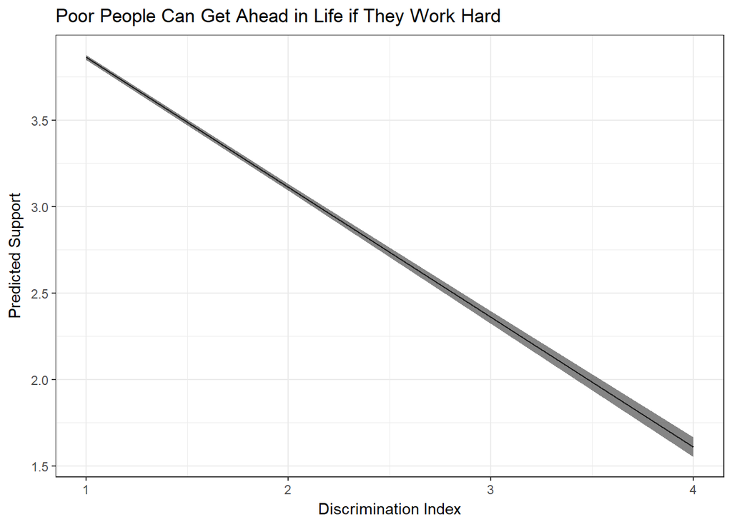

```r
ggplot(plot_predicts2, aes(x = discindx, y = fit,
                        ymin = lwr,
                        ymax= upr)) +
  geom_line() +
  geom_ribbon(alpha = .6) +
  theme_bw() +
  labs(x = "Discrimination Index",
       y = "Predicted Support",
       title = "Poor People Can Get Ahead in Life if They Work Hard")
```

Yes… The more that Latinos experienced discrimination the less they think that it is possible to get ahead in life with hard work. It might be the case that the experience and perceptions of discrimination is also passed down by generation, making further generation more pessimistic.